# Assignment6_Prem

```python
import pandas as pd
import numpy as np
from sklearn import metrics
import matplotlib.pyplot as plt
%matplotlib inline
import warnings
warnings.filterwarnings('ignore')
import seaborn as sns
from sklearn.model_selection import train_test_split
from sklearn.preprocessing import StandardScaler
import tensorflow as tf
import keras
from keras.models import Sequential
from keras.layers import Dense, Dropout
from tensorflow.keras import optimizers
from tensorflow.keras.optimizers import Adam
from sklearn.metrics import confusion_matrix
```

```python
bank_df=pd.read_csv('bank.csv')
```

```python
# copying data to another varaible to avoid any changes to original data
data = bank_df.copy()
```

```python
data.head()
```

|  | RowNumber | CustomerId | Surname | CreditScore | Geography | Gender | Age | Tenure | Balance | NumOfProducts | HasCrCard | IsActiveMember | EstimatedSalary | Exited |
| --- | --- | --- | --- | --- | --- | --- | --- | --- | --- | --- | --- | --- | --- | --- |
| 0 | 1 | 15634602 | Hargrave | 619 | France | Female | 42 | 2 | 0.00 | 1 | 1 | 1 | 101348.88 | 1 |
| 1 | 2 | 15647311 | Hill | 608 | Spain | Female | 41 | 1 | 83807.86 | 1 | 0 | 1 | 112542.58 | 0 |
| 2 | 3 | 15619304 | Onio | 502 | France | Female | 42 | 8 | 159660.80 | 3 | 1 | 0 | 113931.57 | 1 |
| 3 | 4 | 15701354 | Boni | 699 | France | Female | 39 | 1 | 0.00 | 2 | 0 | 0 | 93826.63 | 0 |
| 4 | 5 | 15737888 | Mitchell | 850 | Spain | Female | 43 | 2 | 125510.82 | 1 | 1 | 1 | 79084.10 | 0 |

```python
data.shape
```

```
(10000, 14)
```

```python
data.isnull().sum()
```

```
RowNumber          0
CustomerId         0
Surname            0
CreditScore        0
Geography          0
Gender             0
Age                0
Tenure             0
Balance            0
NumOfProducts      0
HasCrCard          0
IsActiveMember     0
EstimatedSalary    0
Exited             0
dtype: int64
```

We see that there are no null values in the data set.

```python
data.info()
```

```
<class 'pandas.core.frame.DataFrame'>
RangeIndex: 10000 entries, 0 to 9999
Data columns (total 14 columns):
 #   Column           Non-Null Count  Dtype
---  ------           --------------  -----
 0   RowNumber        10000 non-null  int64
 1   CustomerId       10000 non-null  int64
 2   Surname          10000 non-null  object
 3   CreditScore      10000 non-null  int64
 4   Geography        10000 non-null  object
 5   Gender           10000 non-null  object
 6   Age              10000 non-null  int64
 7   Tenure           10000 non-null  int64
 8   Balance          10000 non-null  float64
 9   NumOfProducts    10000 non-null  int64
 10  HasCrCard        10000 non-null  int64
 11  IsActiveMember   10000 non-null  int64
 12  EstimatedSalary  10000 non-null  float64
 13  Exited           10000 non-null  int64
dtypes: float64(2), int64(9), object(3)
memory usage: 1.1+ MB
```

```python
data.nunique()
```

```
RowNumber          10000
CustomerId         10000
Surname             2932
CreditScore          460
Geography              3
Gender                 2
Age                   70
Tenure                11
Balance             6382
NumOfProducts          4
HasCrCard              2
IsActiveMember         2
EstimatedSalary     9999
Exited                 2
dtype: int64
```

There seems to be 6 categorical feature and out of that "Exited" is the target feature.

```python
# Making a list of all categorical variables and geting value counts.
cat_col = [
    "Geography",
    "Gender",
    "NumOfProducts",
    "HasCrCard",
    "IsActiveMember",
    "Exited",
    ]

# Printing number of count of each unique value in each column
for column in cat_col:
    print(data[column].value_counts())
    print("-" * 40)
```

```
France     5014
Germany    2509
Spain      2477
Name: Geography, dtype: int64
----------------------------------------
Male      5457
Female    4543
Name: Gender, dtype: int64
----------------------------------------
1    5084
2    4590
3     266
4      60
Name: NumOfProducts, dtype: int64
----------------------------------------
1    7055
0    2945
Name: HasCrCard, dtype: int64
----------------------------------------
1    5151
0    4849
Name: IsActiveMember, dtype: int64
----------------------------------------
0    7963
1    2037
Name: Exited, dtype: int64
----------------------------------------
```

### Observations:

1. Data is balanced in term of "Geography", "Gender" and "IsActiveMember".
2. Data is little imbalanced in term of "NumOfProducts", "HasCrCard" and "Exited".

```python
data.describe()
```

|  | RowNumber | CustomerId | CreditScore | Age | Tenure | Balance | NumOfProducts | HasCrCard | IsActiveMember | EstimatedSalary | Exited |
| --- | --- | --- | --- | --- | --- | --- | --- | --- | --- | --- | --- |
| count | 10000.00000 | 1.000000e+04 | 10000.000000 | 10000.000000 | 10000.000000 | 10000.000000 | 10000.000000 | 10000.00000 | 10000.000000 | 10000.000000 | 10000.000000 |
| mean | 5000.50000 | 1.569094e+07 | 650.528800 | 38.921800 | 5.012800 | 76485.889288 | 1.530200 | 0.70550 | 0.515100 | 100090.239881 | 0.203700 |
| std | 2886.89568 | 7.193619e+04 | 96.653299 | 10.487806 | 2.892174 | 62397.405202 | 0.581654 | 0.45584 | 0.499797 | 57510.492818 | 0.402769 |
| min | 1.00000 | 1.556570e+07 | 350.000000 | 18.000000 | 0.000000 | 0.000000 | 1.000000 | 0.00000 | 0.000000 | 11.580000 | 0.000000 |
| 25% | 2500.75000 | 1.562853e+07 | 584.000000 | 32.000000 | 3.000000 | 0.000000 | 1.000000 | 0.00000 | 0.000000 | 51002.110000 | 0.000000 |
| 50% | 5000.50000 | 1.569074e+07 | 652.000000 | 37.000000 | 5.000000 | 97198.540000 | 1.000000 | 1.00000 | 1.000000 | 100193.915000 | 0.000000 |
| 75% | 7500.25000 | 1.575323e+07 | 718.000000 | 44.000000 | 7.000000 | 127644.240000 | 2.000000 | 1.00000 | 1.000000 | 149388.247500 | 0.000000 |
| max | 10000.00000 | 1.581569e+07 | 850.000000 | 92.000000 | 10.000000 | 250898.090000 | 4.000000 | 1.00000 | 1.000000 | 199992.480000 | 1.000000 |

```python
data.describe(include=['object'])
```

|  | Surname | Geography | Gender |
| --- | --- | --- | --- |
| count | 10000 | 10000 | 10000 |
| unique | 2932 | 3 | 2 |
| top | Smith | France | Male |
| freq | 32 | 5014 | 5457 |

# Perform an Exploratory Data Analysis on the data

```python
#Row number, CustomerId and Surname are useless column. We will drop this column.
data.drop(['RowNumber','CustomerId','Surname'],axis=1,inplace=True)
```

```python
# While doing uni-variate analysis of numerical variables we want to study their central tendency
# and dispersion.
# Let us write a function that will help us create boxplot and histogram for any input numerical
# variable.
# This function takes the numerical column as the input and returns the boxplots
# and histograms for the variable.
# Let us see if this help us write faster and cleaner code.
def histogram_boxplot(feature, figsize=(15, 10), bins=None):
    """Boxplot and histogram combined
    feature: 1-d feature array
    figsize: size of fig (default (9,8))
    bins: number of bins (default None / auto)
    """
    f2, (ax_box2, ax_hist2) = plt.subplots(
        nrows=2,  # Number of rows of the subplot grid= 2
        sharex=True,  # x-axis will be shared among all subplots
        gridspec_kw={"height_ratios": (0.25, 0.75)},
        figsize=figsize,
    )  # creating the 2 subplots
    sns.boxplot(
        feature, ax=ax_box2, showmeans=True, color="violet"
    )  # boxplot will be created and a star will indicate the mean value of the column
    sns.distplot(
        feature, kde=F, ax=ax_hist2, bins=bins, palette="winter"
    ) if bins else sns.distplot(
        feature, kde=False, ax=ax_hist2
    )  # For histogram
    ax_hist2.axvline(
        np.mean(feature), color="green", linestyle="--"
    )  # Add mean to the histogram
    ax_hist2.axvline(
        np.median(feature), color="black", linestyle="-"
    )  # Add median to the histogram
```

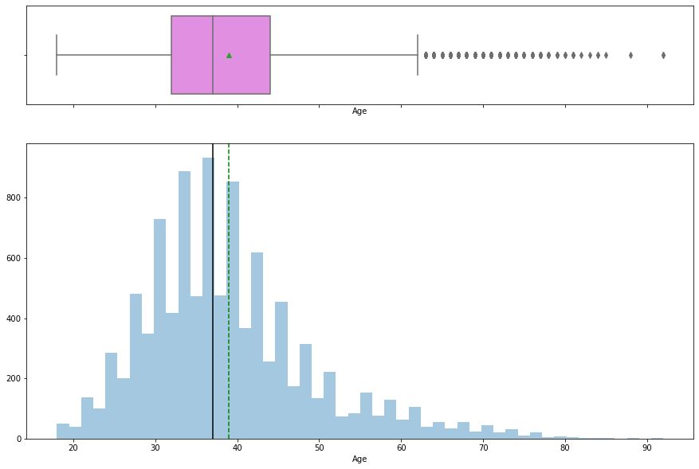

```python
histogram_boxplot(data["Age"])
```

- The distribution is slightly right skewed.
- There are very few customers of age 90+.

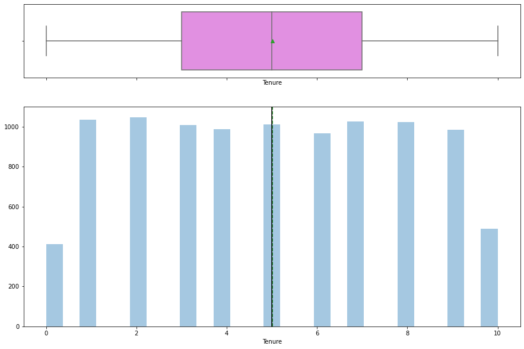

```python
histogram_boxplot(data["Tenure"])
```

- Tenure variable has rectangular distribution.
- This means all the value of tenure is equally likely.

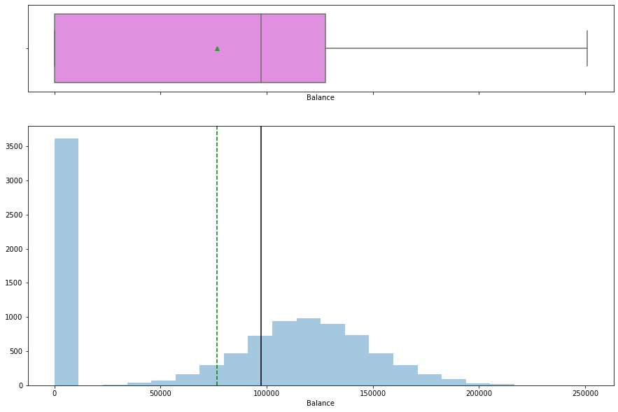

```python
histogram_boxplot(data["Balance"])
```

- This varibale has two concentration of data.
- One around 0-1000 with the count of 3600.
- The other set of data is normally distributed around 125000 with highest count of 1000.

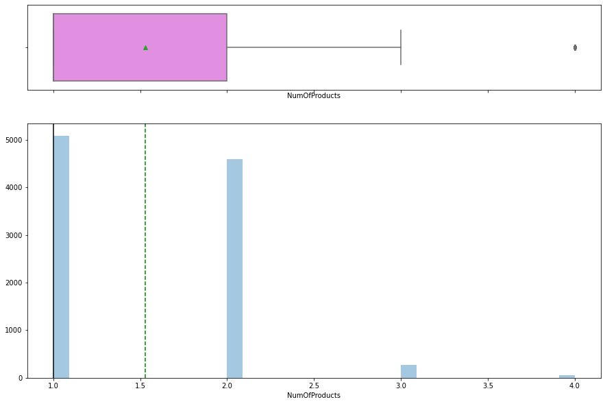

```python
histogram_boxplot(data["NumOfProducts"])
```

- Most customes have either one or two products.
- Very few customers have 3 or 4 products.

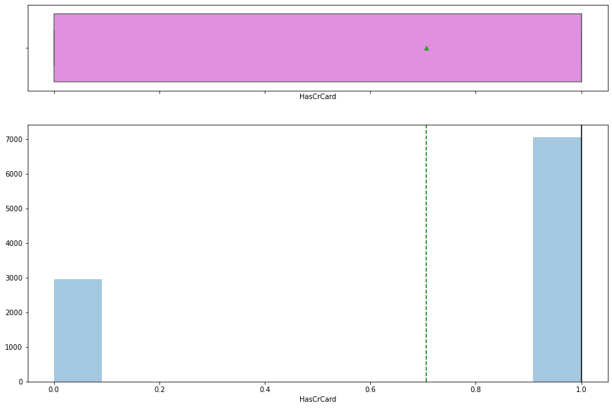

```python
histogram_boxplot(data["HasCrCard"])
```

- Around 7000 customers have card and 3000 dont have card.

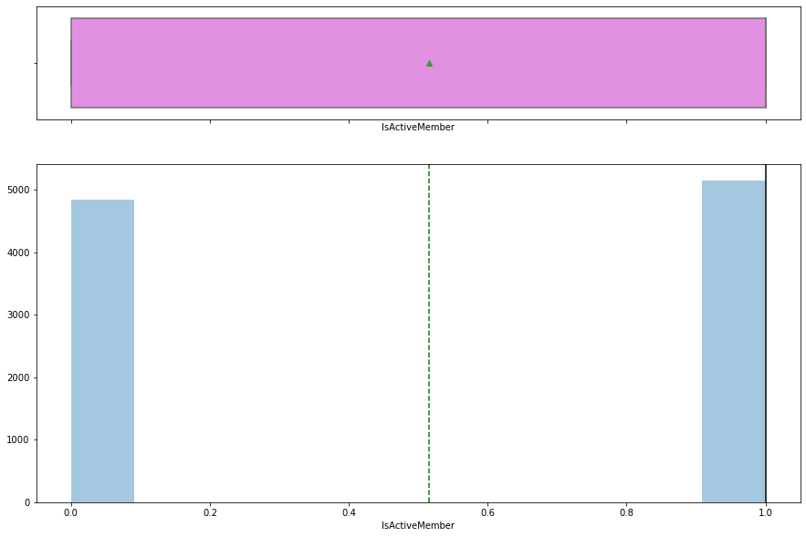

```python
histogram_boxplot(data["IsActiveMember"])
```

- Half of the customers are active members and half are not active member.

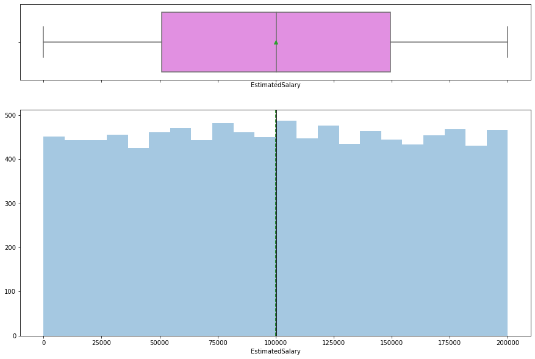

```python
histogram_boxplot(data["EstimatedSalary"])
```

- Estimated salary has rectangular distribution.
- This means all the value are equally likely.

```python
def perc_on_bar(feature):
    """
    plot
    feature: categorical feature
    the function won't work if a column is passed in hue parameter
    """
    # Creating a countplot for the feature
    sns.set(rc={"figure.figsize": (10, 5)})
    ax = sns.countplot(x=feature, data=data)

    total = len(feature)  # length of the column
    for p in ax.patches:
        percentage = "{:.1f}%".format(
            100 * p.get_height() / total
        )  # percentage of each class of the category
        x = p.get_x() + p.get_width() / 2 - 0.1  # width of the plot
        y = p.get_y() + p.get_height()  # hieght of the plot
        ax.annotate(percentage, (x, y), size=14)  # annotate the percantage

    plt.show()  # show the plot
```

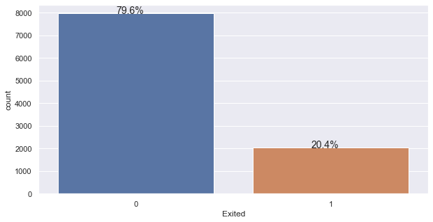

```python
perc_on_bar(data["Exited"])
```

- 20.4% of the customers exited.

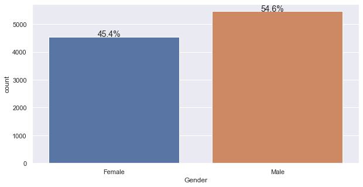

```python
perc_on_bar(data["Gender"])
```

- Male customers are liilte more than Female customers.

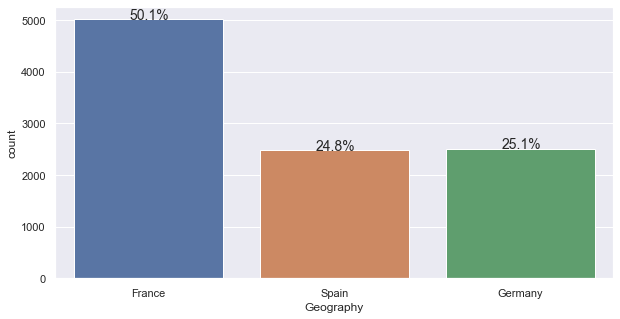

```python
perc_on_bar(data["Geography"])
```

- Approximately half of the customers are form France.
- Rest half of the customer are from Spain and Germany divided approximately equally.

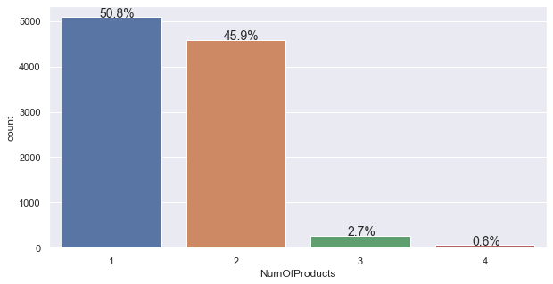

```python
perc_on_bar(data["NumOfProducts"])
```

- 96.7% of customers have one or two products.

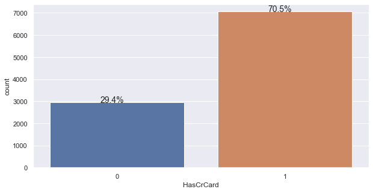

```python
perc_on_bar(data["HasCrCard"])
```

- 70.5% customers have card and 29.4% don't.

### Bivariate Analysis

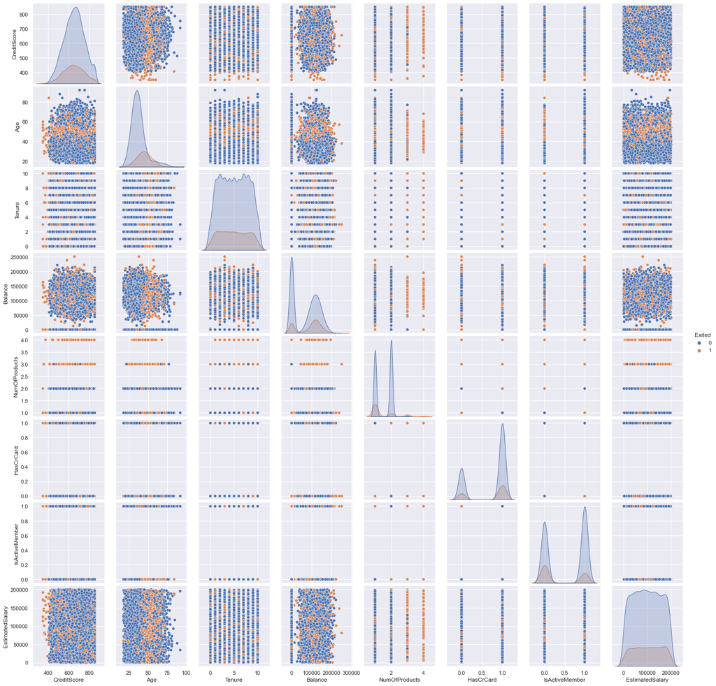

```python
#sns.set_style("whitegrid");
sns.pairplot(data, hue='Exited')
```

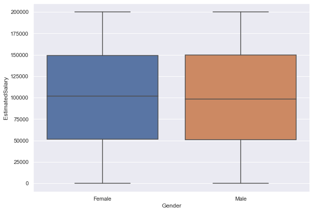

```python
sns.set(rc={"figure.figsize": (10, 7)})
sns.boxplot(y="EstimatedSalary", x="Gender", data=data)
```

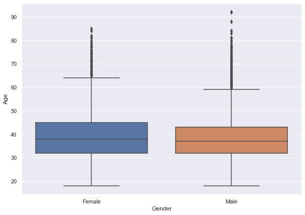

```python
sns.boxplot(y="Age", x="Gender", data=data)
```

- The mean age of male is slightly lower than femal customers.
- The outlier person of 90+ year old is a male customer.

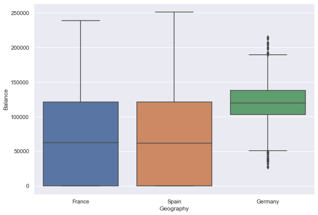

```python
sns.boxplot(y="Balance", x="Geography", data=data)
```

- Customers from France and Spain have similar distribution of their balnces.
- Customers from Germany have higher mean balnce from other two geography. However the max value is lower than Fance and Spain.

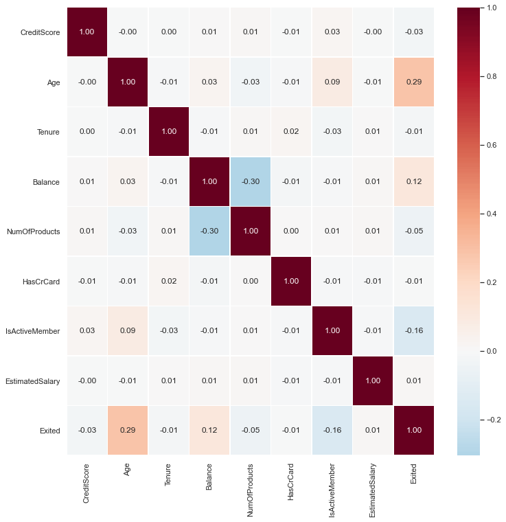

```python
sns.set(rc={"figure.figsize": (12, 12)})
sns.heatmap(
    data.corr(),
    annot=True,
    linewidths=0.5,
    center=0,
    cbar=True,
    cmap="RdBu_r",
    fmt="0.2f",
)
plt.show()
```

- None of the varibales have any strong correlation between them.

### Getting data ready for modelling

```python
#One hot encoding the non numerical columns
data= pd.get_dummies(data, columns=['Geography', 'Gender'])
```

#### Split the data

```python
X = data.drop(['Exited'],axis=1)
y = data['Exited']
```

```python
# Splitting data into training and test set:
X_train, X_test, y_train, y_test = train_test_split(X, y, test_size=0.3, random_state=7,stratify=y)
print(X_train.shape, X_test.shape)
```

```
(7000, 13) (3000, 13)
```

```python
sc = StandardScaler()
X_train = sc.fit_transform(X_train)
X_test = sc.transform(X_test)
```

**Before building the model, let's create functions to calculate different metrics- Accuracy, Recall and Precision and plot the confusion matrix.**

```python
def make_confusion_matrix(cf,
                          group_names=None,
                          categories='auto',
                          count=True,
                          percent=True,
                          cbar=True,
                          xyticks=True,
                          xyplotlabels=True,
                          sum_stats=True,
                          figsize=None,
                          cmap='Blues',
                          title=None):
    '''
    This function will make a pretty plot of an sklearn Confusion Matrix cm using a Seaborn heatmap visualization.
    Arguments
    '''


    # CODE TO GENERATE TEXT INSIDE EACH SQUARE
    blanks = ['' for i in range(cf.size)]

    if group_names and len(group_names)==cf.size:
        group_labels = ["{}\n".format(value) for value in group_names]
    else:
        group_labels = blanks

    if count:
        group_counts = ["{0:0.0f}\n".format(value) for value in cf.flatten()]
    else:
        group_counts = blanks

    if percent:
        group_percentages = ["{0:.2%}".format(value) for value in cf.flatten()/np.sum(cf)]
    else:
        group_percentages = blanks

    box_labels = [f"{v1}{v2}{v3}".strip() for v1, v2, v3 in zip(group_labels,group_counts,group_percentages)]
    box_labels = np.asarray(box_labels).reshape(cf.shape[0],cf.shape[1])


    # CODE TO GENERATE SUMMARY STATISTICS & TEXT FOR SUMMARY STATS
    if sum_stats:
        #Accuracy is sum of diagonal divided by total observations
        accuracy  = np.trace(cf) / float(np.sum(cf))

        #if it is a binary confusion matrix, show some more stats
        if len(cf)==2:
            #Metrics for Binary Confusion Matrices
            precision = cf[1,1] / sum(cf[:,1])
            recall    = cf[1,1] / sum(cf[1,:])
            f1_score  = 2*precision*recall / (precision + recall)
            stats_text = "\n\nAccuracy={:0.3f}\nPrecision={:0.3f}\nRecall={:0.3f}\nF1 Score={:0.3f}".format(
                accuracy,precision,recall,f1_score)
        else:
            stats_text = "\n\nAccuracy={:0.3f}".format(accuracy)
    else:
        stats_text = ""


    # SET FIGURE PARAMETERS ACCORDING TO OTHER ARGUMENTS
    if figsize==None:
        #Get default figure size if not set
        figsize = plt.rcParams.get('figure.figsize')

    if xyticks==False:
        #Do not show categories if xyticks is False
        categories=False


    # MAKE THE HEATMAP VISUALIZATION
    plt.figure(figsize=figsize)
    sns.heatmap(cf,annot=box_labels,fmt="",cmap=cmap,cbar=cbar,xticklabels=categories,yticklabels=categories)

    if xyplotlabels:
        plt.ylabel('True label')
        plt.xlabel('Predicted label' + stats_text)
    else:
        plt.xlabel(stats_text)

    if title:
        plt.title(title)
```

### Model building

```python
model = Sequential()
```

```python
# Adding the input layer and the first hidden layer
model.add(Dense(units = 5, activation = 'relu', input_dim = 13))
# Adding the second hidden layer
model.add(Dense(units = 6, activation = 'relu'))
# Adding the output layer
model.add(Dense(units = 1, activation = 'sigmoid'))
# Compiling the ANN
model.compile(optimizer = 'adam', loss = 'binary_crossentropy', metrics = ['accuracy'])
#Print model summary
model.summary()
```

```
Model: "sequential"
_________________________________________________________________
Layer (type)                 Output Shape              Param #
=================================================================
dense (Dense)                (None, 5)                 70
_________________________________________________________________
dense_1 (Dense)              (None, 6)                 36
_________________________________________________________________
dense_2 (Dense)              (None, 1)                 7
=================================================================
Total params: 113
Trainable params: 113
Non-trainable params: 0
_________________________________________________________________
```

```python
# Fitting the ANN to the Training set
history = model.fit(X_train, y_train, batch_size = 50, epochs = 50,validation_split=0.2)
```

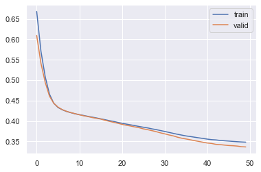

```python
# Capturing learning history per epoch
hist  = pd.DataFrame(history.history)
hist['epoch'] = history.epoch

# Plotting accuracy at different epochs
plt.plot(hist['loss'])
plt.plot(hist['val_loss'])
plt.legend(("train" , "valid") , loc =0)
```

#### Evaluation

Keras model can be evaluated with evaluate() function

Evaluation results are contained in a list

```python
score1 = model.evaluate(X_test, y_test)
```

- The model achieves an accuracy of 86% !

```python
print(score1)
```

```
[0.36199715733528137, 0.8606666922569275]
```

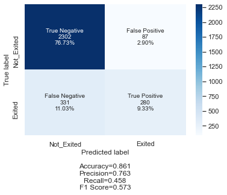

```python
## Confusion Matrix on unsee test set
import seaborn as sn
y_pred1 = model.predict(X_test)
for i in range(len(y_test)):
    if y_pred1[i]>0.5:
        y_pred1[i]=1
    else:
        y_pred1[i]=0



cm2=confusion_matrix(y_test, y_pred1)
labels = ['True Negative','False Positive','False Negative','True Positive']
categories = [ 'Not_Exited','Exited']
make_confusion_matrix(cm2,
                      group_names=labels,
                      categories=categories,
                      cmap='Blues')
```

**Observation**

### Let's try another architecture to get the better Recall

- There are some basic Hyperparameters which can help to get the better model performance.

**Early stopping:**

- During training, the model is evaluated on a holdout validation dataset after each epoch. If the performance of the model on the validation dataset starts to degrade or no improvement (e.g. loss begins to increase or accuracy begins to decrease), then the training process is stopped after the certian interations.The model at the time that training is stopped is then used and is known to have good generalization performance.
- This procedure is called “early stopping” and is perhaps one of the oldest and most widely used forms of neural network regularization.

**Weight Initialization**

- Weight initialization is an important consideration in the design of a neural network model.
- The nodes in neural networks are composed of parameters referred to as weights used to calculate a weighted sum of the inputs.
- Neural network models are fit using an optimization algorithm called stochastic gradient descent that incrementally changes the network weights to minimize a loss function, hopefully resulting in a set of weights for the mode that is capable of making useful predictions.
- This optimization algorithm requires a starting point in the space of possible weight values from which to begin the optimization process. Weight initialization is a procedure to set the weights of a neural network to small random values that define the starting point for the optimization (learning or training) of the neural network model.
- There are many WI techniques as follows:

  1) Random normal initialization

  2) Random Uniform initialization

  3) Xaviour Initialization

  4) He Initialization

```python
#Training Multi-layer perceptron with 2 hidden layers

#adding earlystopping callback
es= keras.callbacks.EarlyStopping(monitor='val_loss',
                              min_delta=0,
                              patience=15,
                             verbose=0, mode='min', restore_best_weights= True)
Model2 = Sequential()
#Initializing the weights uisng hue_normal
Model2.add(Dense(10, input_shape=(13, ), kernel_initializer='he_normal', activation='relu'))
Model2.add(Dropout(0.5))
Model2.add(Dense(12, kernel_initializer='he_normal', activation='relu'))
Model2.add(Dropout(0.5))
Model2.add(Dense(1, kernel_initializer='he_normal', activation='sigmoid'))

Model2.compile(optimizer= 'adam', loss='binary_crossentropy', metrics=['accuracy'])

his_mod2= Model2.fit(X_train, y_train, validation_split=0.2, batch_size=50, epochs=50, callbacks=[es], shuffle=True, verbose=1)
```

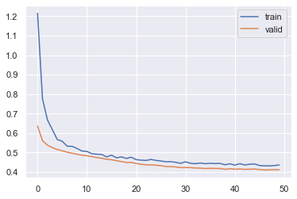

```python
# Capturing learning history per epoch
hist  = pd.DataFrame(his_mod2.history)
hist['epoch'] = his_mod2.epoch

# Plotting accuracy at different epochs
plt.plot(hist['loss'])
plt.plot(hist['val_loss'])
plt.legend(("train" , "valid") , loc =0)
```

```python
score = Model2.evaluate(X_test, y_test)
```

- The model accuracy is reduced to 79.8%.

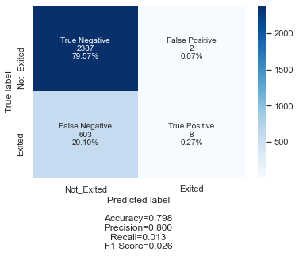

```python
import seaborn as sn
y_pred2 = Model2.predict(X_test)
for i in range(len(y_test)):
    if y_pred2[i]>0.5:
        y_pred2[i]=1
    else:
        y_pred2[i]=0



cm2=confusion_matrix(y_test, y_pred2)
labels = ['True Negative','False Positive','False Negative','True Positive']
categories = [ 'Not_Exited','Exited']
make_confusion_matrix(cm2,
                      group_names=labels,
                      categories=categories,
                      cmap='Blues')
```

**Observation**

- Precision is improved but test recall is very low.
- There were 603 customers who exited but were predited as Not-Exited. And there were only 8 customers who were correctly identified as Exited.
- The performance of this model degraded compare dto previous one.

### Weighted loss to account for large class imbalance in train dataset

The given data set is imbalanced in terms of 'Exited' customers. Lets adjust the class imbalance by giving additional weight to the loss associated to errors made on Exited customres misclassification.

Let apply weighted loss to our first ANN model.

```python
from sklearn.utils import class_weight
class_weights = class_weight.compute_class_weight('balanced', np.unique(y_train), np.array([y_train.iloc[i] for i in range(len(y_train))]))
class_weights = dict(enumerate(class_weights))
class_weights
```

```
{0: 0.6279153211338356, 1: 2.4544179523141656}
```

```python
history3= model.fit(X_train,y_train,batch_size = 50, epochs = 50, class_weight=class_weights, shuffle=True)
```

```python
score = model.evaluate(X_test, y_test)
```

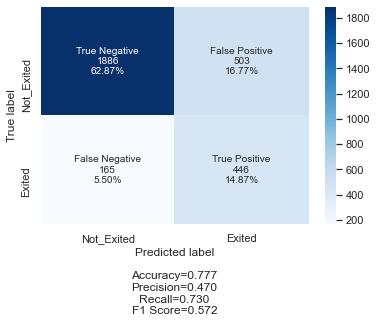

```python
import seaborn as sn
y_pred2 = model.predict(X_test)
for i in range(len(y_test)):
    if y_pred2[i]>0.5:
        y_pred2[i]=1
    else:
        y_pred2[i]=0



cm2=confusion_matrix(y_test, y_pred2)
labels = ['True Negative','False Positive','False Negative','True Positive']
categories = [ 'Not_Exited','Exited']
make_confusion_matrix(cm2,
                      group_names=labels,
                      categories=categories,
                      cmap='Blues')
```

**Observation**

- Precision is reduced but test recall is improved considerably.
- There were only 165 customers who exited but were predited as Not-Exited. And there were 446 customers who were correctly identified as Exited.

### Conclusion:

As we can see here the Recall is increased but the precision is very bad. There is still lot of scope of improvements as follows:

```
1) Threshold can be tuned to get the optimal value

2) Resampling techniques can be applied to balanced the data and then train the model

3) Hyperparameter tuning can be applied to tune the different Hyperparameters
```

We can select the Model-3 as our final model based on the above analysis.